# team.Rmd

Grant Ruedy & Andrew Sundberg

2/19/2019

```r
data(happy, package="productplots")
head(happy)
```

```
##   id         happy year age    sex       marital         degree
## 1  1 not too happy 1972  23 female never married       bachelor
## 2  2 not too happy 1972  70   male       married lt high school
## 3  3  pretty happy 1972  48 female       married    high school
## 4  4 not too happy 1972  27 female       married       bachelor
## 5  5  pretty happy 1972  61 female       married    high school
## 6  6  pretty happy 1972  26   male never married    high school
##         finrela    health wtssall
## 1       average      good  0.4446
## 2 above average      fair  0.8893
## 3       average excellent  0.8893
## 4       average      good  0.8893
## 5 above average      good  0.8893
## 6 above average      good  0.4446
```

```r
HAPPY <- readRDS("HAPPY.rds")
```

```r
HAPPY[HAPPY=='IAP' | HAPPY=='DK'] <- NA
```

2 & 3.

```r
str(HAPPY)
```

```
## 'data.frame':    62466 obs. of  11 variables:
##  $ HAPPY   : chr  "NOT TOO HAPPY" "NOT TOO HAPPY" "PRETTY HAPPY" "NOT TOO HAPPY" ...
##  $ YEAR    : int  1972 1972 1972 1972 1972 1972 1972 1972 1972 1972 ...
##  $ AGE     : chr  "23" "70" "48" "27" ...
##  $ SEX     : chr  "FEMALE" "MALE" "FEMALE" "FEMALE" ...
##  $ MARITAL : chr  "NEVER MARRIED" "MARRIED" "MARRIED" "MARRIED" ...
##  $ DEGREE  : chr  "BACHELOR" "LT HIGH SCHOOL" "HIGH SCHOOL" "BACHELOR" ...
##  $ FINRELA : chr  "AVERAGE" "ABOVE AVERAGE" "AVERAGE" "AVERAGE" ...
##  $ HEALTH  : chr  "GOOD" "FAIR" "EXCELLENT" "GOOD" ...
##  $ WTSSALL : num  0.445 0.889 0.889 0.889 0.889 ...
##  $ PARTYID : chr  "IND,NEAR DEM" "NOT STR DEMOCRAT" "INDEPENDENT" "NOT STR DEMOCRAT" ...
##  $ POLVIEWS: chr  NA NA NA NA ...
```

```r
happy1 <- as.character(HAPPY$HAPPY)
HAPPY$HAPPY <-factor(happy1)

sex1 <- as.character(HAPPY$SEX)
sex2 <- factor(sex1)
str(sex2)
```

```
##  Factor w/ 2 levels "FEMALE","MALE": 1 2 1 1 1 2 2 2 1 1 ...
```

```r
levels(sex2)
```

```
## [1] "FEMALE" "MALE"
```

```r
HAPPY$SEX <-sex2

marital1 <- as.character(HAPPY$MARITAL)
marital2 <- factor(marital1, c('NEVER MARRIED', 'MARRIED', 'SEPARATED', 'DIVORCED', 'WIDOWED'))
str(marital2)
```

```
##  Factor w/ 5 levels "NEVER MARRIED",..: 1 2 2 2 2 1 4 1 1 2 ...
```

```r
levels(marital2)
```

```
## [1] "NEVER MARRIED" "MARRIED"       "SEPARATED"     "DIVORCED"
## [5] "WIDOWED"
```

```r
HAPPY$MARITAL <- marital2

degree1 <- as.character(HAPPY$DEGREE)
degree2 <- factor(degree1, c('LT HIGH SCHOOL', 'HIGH SCHOOL', 'JUNIOR COLLEGE', 'BACHELOR', 'GRADUATE'))
str(degree2)
```

```
##  Factor w/ 5 levels "LT HIGH SCHOOL",..: 4 1 2 4 2 2 2 4 2 2 ...
```

```r
levels(degree2)
```

```
## [1] "LT HIGH SCHOOL" "HIGH SCHOOL"    "JUNIOR COLLEGE" "BACHELOR"
## [5] "GRADUATE"
```

```r
HAPPY$DEGREE <-degree2

finrela1 <- as.character(HAPPY$FINRELA)
finrela2 <- factor(finrela1, c('FAR BELOW AVERAGE', 'BELOW AVERAGE', 'AVERAGE', 'ABOVE AVERAGE', 'FAR ABOVE AVERAGE'))
str(finrela2)
```

```
##  Factor w/ 5 levels "FAR BELOW AVERAGE",..: 3 4 3 3 4 4 4 3 3 2 ...
```

```r
levels(finrela2)
```

```
## [1] "FAR BELOW AVERAGE" "BELOW AVERAGE"     "AVERAGE"
## [4] "ABOVE AVERAGE"     "FAR ABOVE AVERAGE"
```

```r
HAPPY$FINRELA <-finrela2

health1 <- as.character(HAPPY$HEALTH)
health2 <- factor(health1, c('POOR', 'FAIR', 'GOOD', 'EXCELLENT'))
str(health2)
```

```
##  Factor w/ 4 levels "POOR","FAIR",..: 3 2 4 3 3 3 4 3 4 2 ...
```

```r
levels(health2)
```

```
## [1] "POOR"      "FAIR"      "GOOD"      "EXCELLENT"
```

```r
HAPPY$HEALTH <-health2

party1 <- as.character(HAPPY$PARTYID)
party2 <- factor(party1, c('STRONG DEMOCRAT', 'NOT STR DEMOCRAT', 'IND,NEAR DEM', 'INDEPENDENT', 'IND,NEAR REP', 'NOT STR REPUBLICAN', 'STRONG REPUBLICAN', 'OTHER PARTY'))
str(party2)
```

```
##  Factor w/ 8 levels "STRONG DEMOCRAT",..: 3 2 4 2 1 3 3 3 1 1 ...
```

```r
levels(party2)
```

```
## [1] "STRONG DEMOCRAT"    "NOT STR DEMOCRAT"   "IND,NEAR DEM"
## [4] "INDEPENDENT"        "IND,NEAR REP"       "NOT STR REPUBLICAN"
## [7] "STRONG REPUBLICAN"  "OTHER PARTY"
```

```r
HAPPY$PARTYID <-party2


HAPPY[HAPPY =='89 OR OLDER'] <- '89'

HAPPY$AGE <- as.numeric(HAPPY$AGE)
str(HAPPY)
```

```
## 'data.frame':    62466 obs. of  11 variables:
##  $ HAPPY   : Factor w/ 3 levels "NOT TOO HAPPY",..: 1 1 2 1 2 2 1 1 2 2 ...
##  $ YEAR    : int  1972 1972 1972 1972 1972 1972 1972 1972 1972 1972 ...
##  $ AGE     : num  23 70 48 27 61 26 28 27 21 30 ...
##  $ SEX     : Factor w/ 2 levels "FEMALE","MALE": 1 2 1 1 1 2 2 2 1 1 ...
##  $ MARITAL : Factor w/ 5 levels "NEVER MARRIED",..: 1 2 2 2 2 1 4 1 1 2 ...
##  $ DEGREE  : Factor w/ 5 levels "LT HIGH SCHOOL",..: 4 1 2 4 2 2 2 4 2 2 ...
##  $ FINRELA : Factor w/ 5 levels "FAR BELOW AVERAGE",..: 3 4 3 3 4 4 4 3 3 2 ...
##  $ HEALTH  : Factor w/ 4 levels "POOR","FAIR",..: 3 2 4 3 3 3 4 3 4 2 ...
##  $ WTSSALL : num  0.445 0.889 0.889 0.889 0.889 ...
##  $ PARTYID : Factor w/ 8 levels "STRONG DEMOCRAT",..: 3 2 4 2 1 3 3 3 1 1 ...
##  $ POLVIEWS: chr  NA NA NA NA ...
```

## Team Exploration

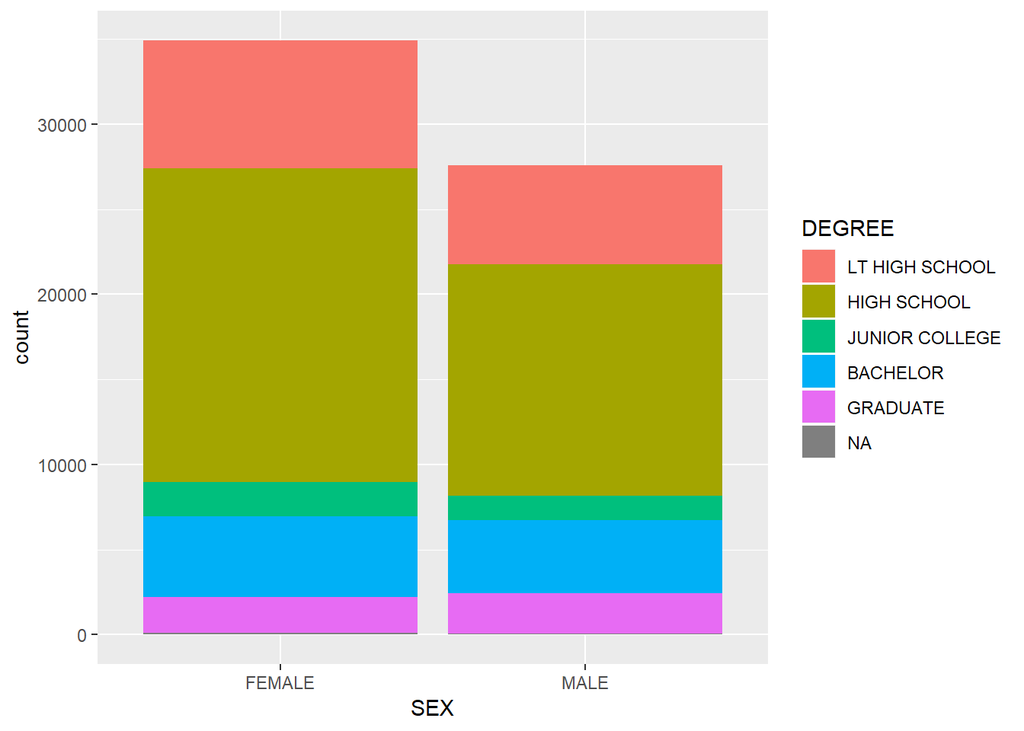

```r
library(ggplot2)

#Investigating Distribution of DEGREE based on SEX
ggplot(HAPPY, aes(x=SEX, fill=DEGREE)) + geom_bar()
```

The first graph shows the relationship between sex and level of degree the person obtained. It is a bar graph, and shows that more women had light high school and high school as their highest level of degree. Men and women had about the same amount of other levels of education though.

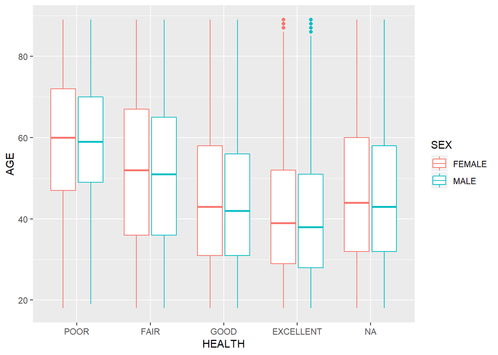

```r
library(ggplot2)

#Investigating Distribution of HEALTH
ggplot(HAPPY, aes(x=HEALTH, y=AGE, col=SEX, size=AGE )) + geom_boxplot(na.rm=TRUE)
```

This graph shows a boxplot comparing the health and age of the person. Each health level is seperated by gender. By looking at the graph, poor health people are the oldest. Fair health pople are the second oldest and this trend continues, for the youngest peope around age 38 have excellent health. This is intuitive that young people are healthier and oldder people tend to be less healthy.

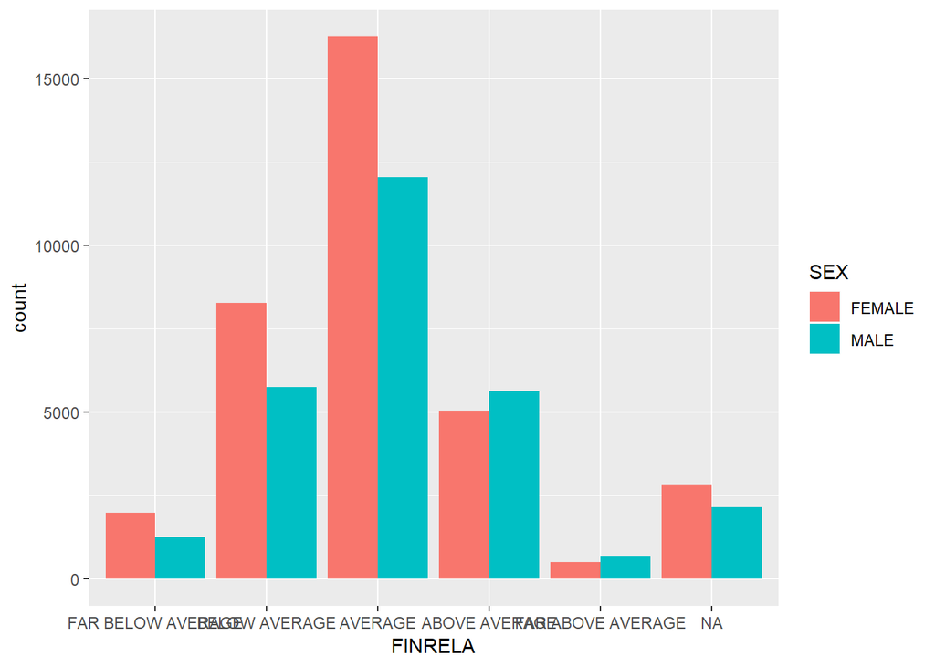

```r
ggplot(HAPPY, aes(x = FINRELA, fill = SEX)) + geom_bar(position = 'dodge')
```

This barplot shows the number of males and females at each financial level. It shows more males with above average and far above average incomes. This shows that males get paid more than females on average.

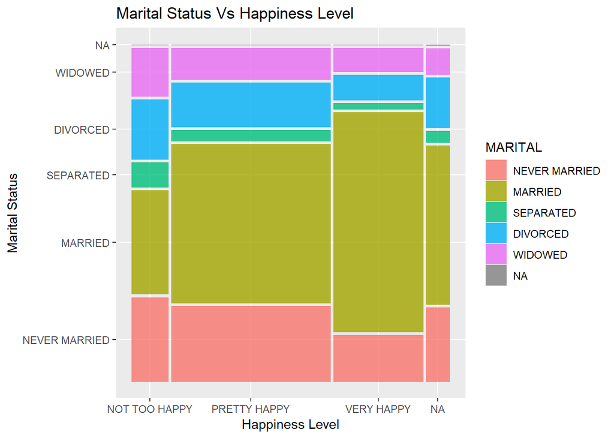

```r
library(ggplot2)
library(ggmosaic)
ggplot(HAPPY) + geom_mosaic(aes(x=product(HAPPY), fill=MARITAL)) + xlab('Happiness Level')+ ylab('Marital Status') + ggtitle('Marital Status Vs Happiness Level')
```

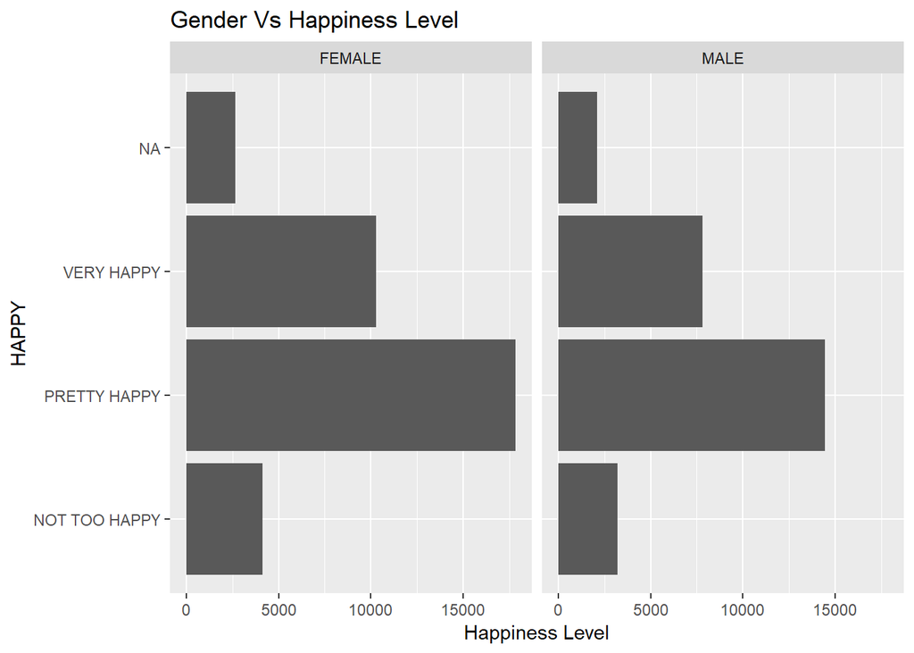

```r
library(ggplot2)

ggplot(HAPPY, aes(x=HAPPY )) + geom_histogram(stat='count') +facet_wrap(~SEX) +coord_flip() +ylab('Happiness Level')+ ggtitle('Gender Vs Happiness Level')
```

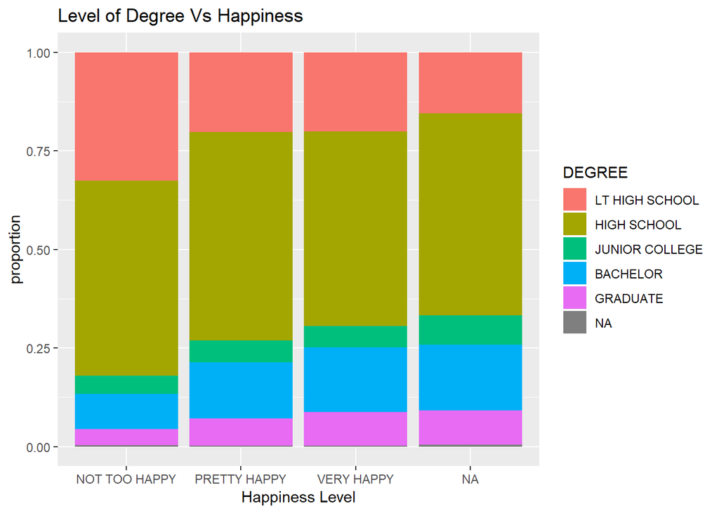

```r
library(ggplot2)

ggplot(HAPPY, aes(x=HAPPY, fill=DEGREE)) + geom_bar(position='fill') + ylab('proportion') + xlab('Happiness Level')+ ggtitle('Level of Degree Vs Happiness')
```

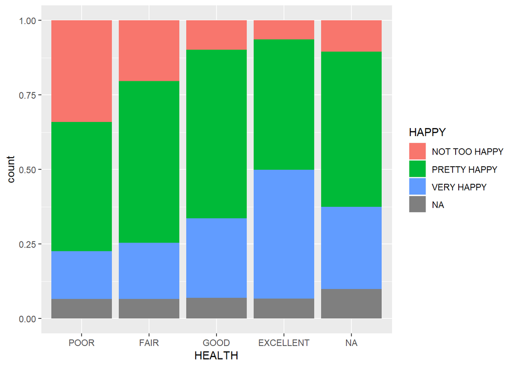

```r
ggplot(HAPPY, aes(x = HEALTH, fill = HAPPY)) + geom_bar(position = 'fill')
```

In this graph it shows the proportion of each happiness level according to each happiness level. We can conclude from this graph that happiness and health have a positive relationship. The “Not Too Happy” proportion gets smaller as the excellent health goes toward excellent.

From the data set, we learned that there is not one factor in someone’s life that can surely dictate their level of happiness. However, there were some trends that were shown by the exploration of this data set. Marital status seemed to play a decently large role in determining someones happiness, and the happiest people were mostly married. This implies being married is a large indicator if someone is happy. If someone was divorce or widowed, that doesn’t mean they were mostly unhappy, though. In terms of comparing happiness levels between the genders, neither one had a higher proprtion in a certain happiness category, implying men and women are about the same happiness level. Education also plays a role in happiness, a people with the lowest level of education (lt high school) were most prominent in the not too happy category. Also, getting a graduate degree seems to increase happines slighly.